# Introduction to R

## Variables

To define variables use either arrow or equalility: (grey boxes are R code, white boxes are the result from grey boxes)

```r
 a <- 2 # beyond hash tages are comments
b  = 3
 print(a)
 print(b)
 print(a*b)
 print(a + b)
```

```
## [1] 2
```

```
## [1] 3
```

```
## [1] 6
```

```
## [1] 5
```

A vector is defined by:

```r
a_vec <- c(4,5,6,7)
 print(a_vec)
zero_vec <- rep(0, 10)
print(zero_vec)
```

```
## [1] 4 5 6 7
```

```
##  [1] 0 0 0 0 0 0 0 0 0 0
```

For a vector one can use indixing to get variables you want:

```r
astar <- a[2:4] #set value 2 to 4 of the vector a_vec as astar
a_vec[10]       #this gives NA, this is dangerous, since a_vec[10] does not exists
random_vector <- c(1,3,5,10,3000,-1,20) # generating number
which.max(random_vector) # which index gives the maximum value of random_vector
which.min(random_vector) # which index gives the minimum value of random_vector
```

## Including Plots

Producing figures:

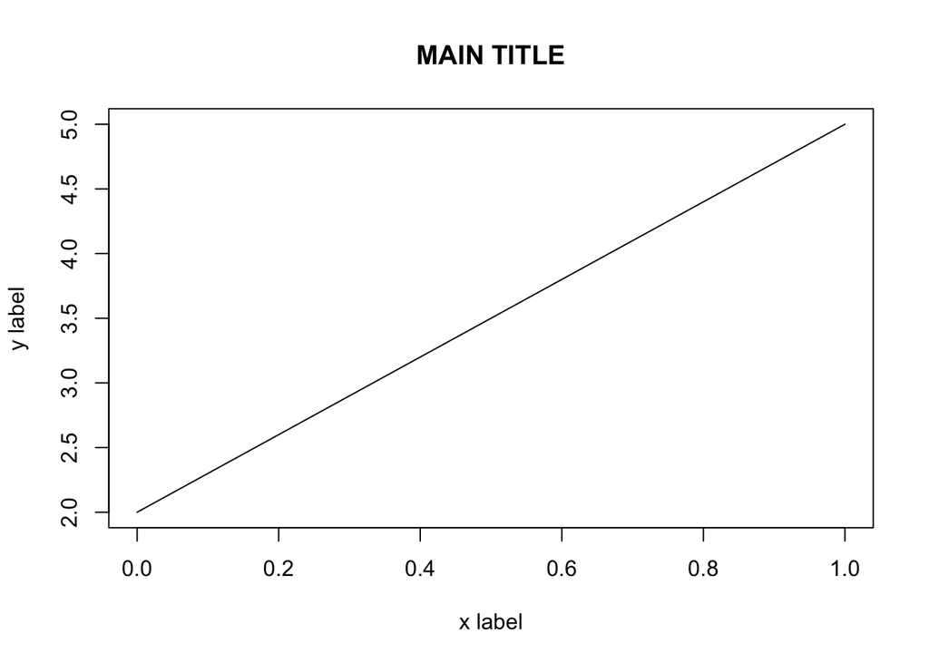

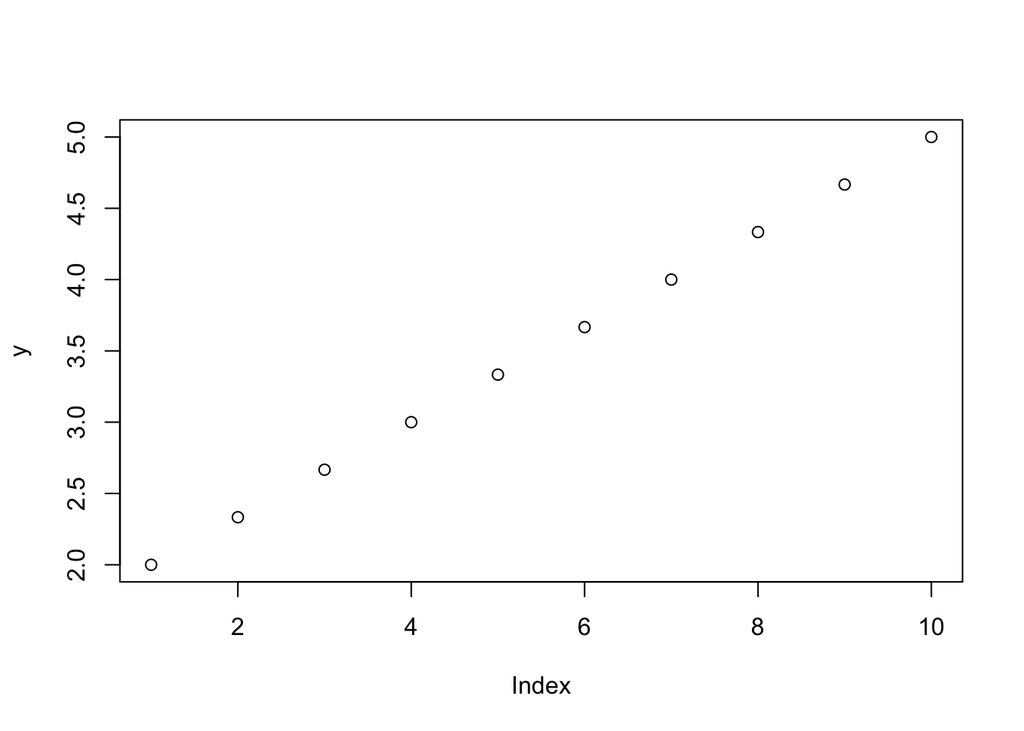

```r
x <- seq(0,1 , length.out = 10) # seq generates a sequence
y <- 3 * x + 2
plot(x, y, type = 'l', xlab = 'x label', ylab = 'y label',  main = 'MAIN TITLE')
#if using plot on a vector only it will be against the index
plot(y)
```

Producing barplot:

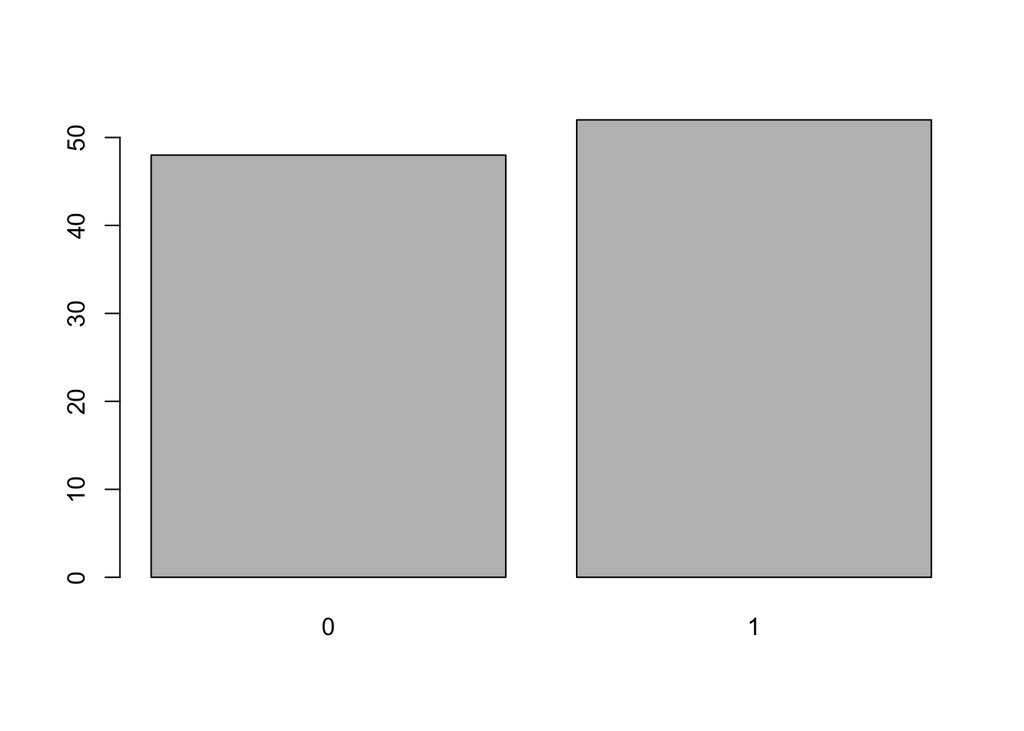

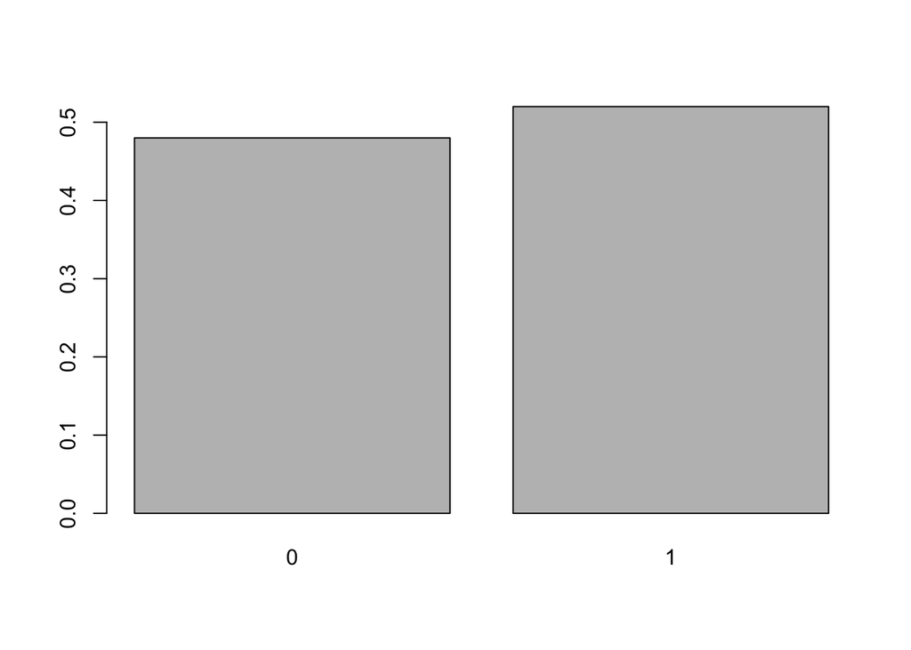

```r
X <- 1 * (runif(n  = 100) < 0.4) # random number U[0,1] which are less than one
tabX <- table(X) #tabulate the data
#simple bar plot from table
barplot(tabX)
#to generate frequencies
barplot(tabX/sum(tabX))
```

## Reading data

To read a file one uses

```r
data <- read.table('stop.txt')
head(data) #head prints the first 6 rows
```

```
##     V1    V2    V3  V4
## 1 prec   pop stops eth
## 2    1  1720   202   1
## 3    1  1368   102   2
## 4    1 23854    81   3
## 5    2  2596   132   1
## 6    2  6844   144   2
```

Often files while have headers, this is something you need to tell read.table

```r
data <- read.table('stop.txt', header = T)
head(data)
```

```
##   prec   pop stops eth
## 1    1  1720   202   1
## 2    1  1368   102   2
## 3    1 23854    81   3
## 4    2  2596   132   1
## 5    2  6844   144   2
## 6    2  9379    71   3
```

If you have data online you can use

```r
link_with_data <- 'https://raw.githubusercontent.com/JonasWallin/BayesianMethods_STAE02/master/lab1/stop.txt'
data <- read.table(url(link_with_data),header=T)
head(data)
```

## Data.frame

The outout is a `data.frame` which contains several different variables forcing them to be the same length. To access a variable of a data frame there exists several options:

```r
#to check the variables one can use:
colnames(data)
```

```
## [1] "prec"  "pop"   "stops" "eth"
```

```r
# to get the variable pop one can use $:
data$prec[1:6]
```

```
## [1] 1 1 1 2 2 2
```

```r
# or:
data[1:6,"prec"]
```

```
## [1] 1 1 1 2 2 2
```

```r
# to access several at the same time
data[1:6,c("prec", "eth")]
```

```
##   prec eth
## 1    1   1
## 2    1   2
## 3    1   3
## 4    2   1
## 5    2   2
## 6    2   3
```

For more instructions see http://thomasleeper.com/Rcourse/Tutorials/dataframes.html.

## Help

Always when using R it important to run the `help` command if you want to know what a function is doing

```r
help(data.frame)
```

## Summary statistics

The basic objects to caculate the mean variance standard deviation

```r
#cat is an other print version
cat('the mean number for the variable stop: ',round(mean(data$stop) ,digits = 2), '\n')
cat('the median number for the variable stop: ',round(median(data$stop) ,digits = 2), '\n')
cat('the standard deviation number for the variable stop: ',round(sd(data$stop) ,digits = 2), '\n')
```

```
## the mean number for the variable stop:  584.09
```

```
## the median number for the variable stop:  385
```

```
## the standard deviation number for the variable stop:  613.79
```

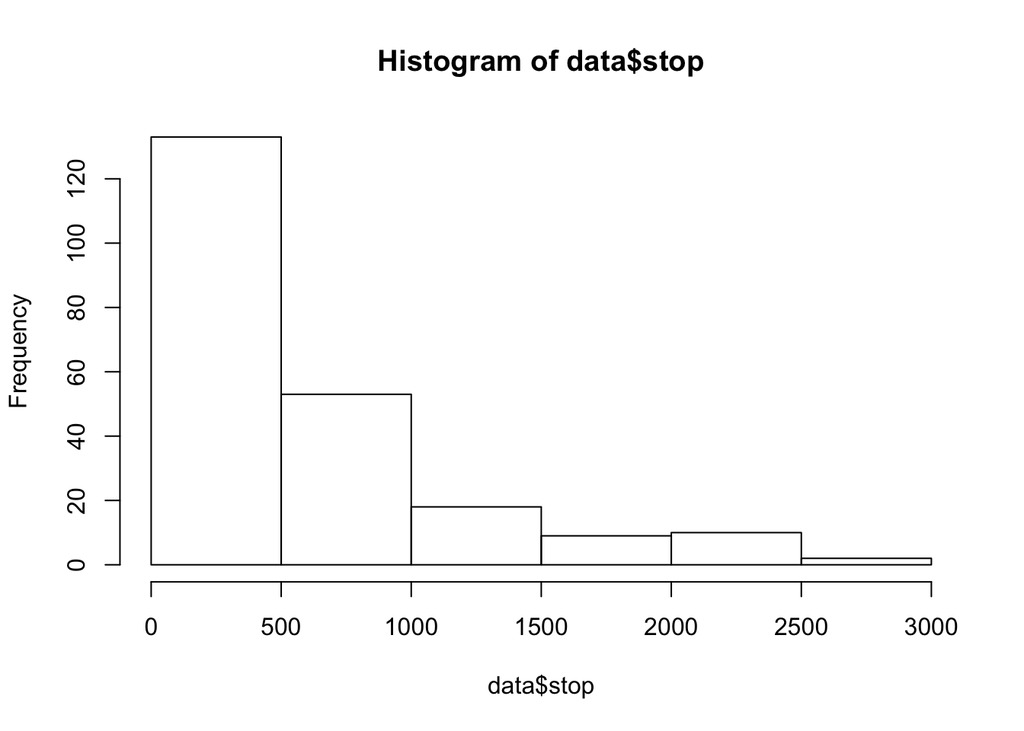

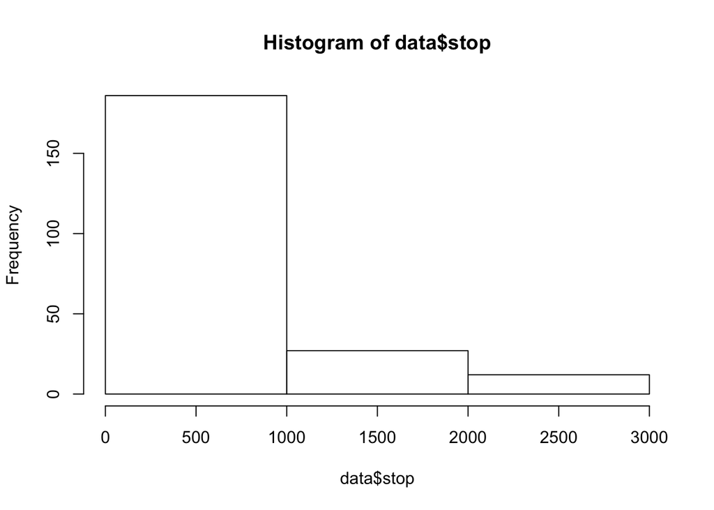

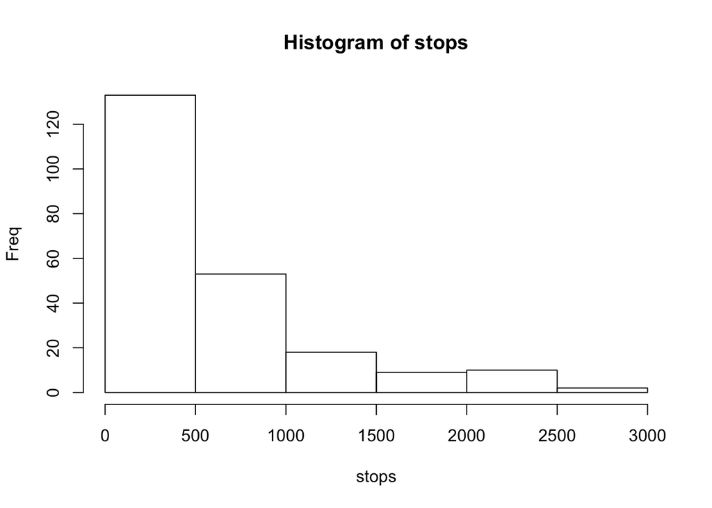

```r
hist(data$stop)
# on define number of bins:
hist(data$stop, breaks = 2)
# one can use the same options for naming labels:
hist(data$stop, xlab=  'stops', ylab='Freq', main='Histogram of stops')
```

## Saving plots and several plots in the same figure

To save a figure you can use `pdf`, `jpeg`, `bmp` or `png` depending what output you want use.

```r
#here only shown for pdf, however all other are identical
filename = 'NAME OF FILE YOU WANT TO SAVE.xxx'
pdf(filename = filename)
plot(hist(data$stop))

dev.off() # this tells R to save the file.
```

The `dev.off()` command is useful if you want to include several lines in the code

## matrices

Matrix is a two dimensional vector. A $m\times n$ matrix $A$ has $m$ rows and $n$ columns. In R matrices are created using

```r
n <- 3
m <- 2
A <- matrix(data = 0, nrow = n, ncol = m)
print(A)
```

```
##      [,1] [,2]
## [1,]    0    0
## [2,]    0    0
## [3,]    0    0
```

```r
A <- matrix(data = 1:(m*n), nrow = n, ncol = m)
print(A)
```

```
##      [,1] [,2]
## [1,]    1    4
## [2,]    2    5
## [3,]    3    6
```

```r
print(A[1,2]) # value of row 1, column 2
```

```
## [1] 4
```

```r
print(A[,1]) #column 1
```

```
## [1] 1 2 3
```

```r
print(A[1,]) #row 1
```

```
## [1] 1 4
```

Using summary statitic can be used on matrices

```r
median(A)
mean(A)
var(A)
sum(A)
```

Often one is intressted in the statistic by row or column

```r
colMeans(A)
rowMeans(A)
rowSums(A)
colSums(A)
```

Foor more matrix details http://thomasleeper.com/Rcourse/Tutorials/matrices.html

## for loop

```r
for(i in 1:4){
  cat('i is now ', i, '\n')
}
```

```
## i is now  1
## i is now  2
## i is now  3
## i is now  4
```

Double loop, this implies

```r
for(i in 1:4){
  for(j in 6:8){
      cat('(i,j) is now (', i,',',j,')\n')
  }
  cat('*********************\n')
}
```

[output not shown]

For a long tutorial on for loops see https://www.r-bloggers.com/a-tutorial-on-loops-in-r-usage-and-alternatives/

## function

R has a lot of functions however you can also build your own:

```r
dumb_loop()
```

[output not shown]

```
## i is now  1
## i is now  2
## i is now  3
## i is now  4
```

You can also put in function arguments:

```r
dumb_loop2 <- function(max = 10){ #deafult value is ten
  for(i in 1:max){
    cat('i is now ', i, '\n')
  }
}

dumb_loop2(1)
```

```
## i is now  1
```

Several argumentes:

```r
dumb_loop3 <- function(max, min = 1){ #only deafult value on min, so one argument must be passed
  for(i in min:max){
    cat('i is now ', i, '\n')
  }
}

dumb_loop3(2,0)
```

```
## i is now  0
## i is now  1
## i is now  2
```

## Libraries

If you search over the internet you will find a huge number of packages that can be used with R. To install (need only done once) do:

```r
package_name = "car" #install the package car
install.packages(package_name)
```

Now you can load the package and use the function inside using:

```r
libary(cars) #load the package
Y<-logit(0.1) #the logit function is not automatic in R but exists in the package car
# Description of the function logit https://en.wikipedia.org/wiki/Logit
```